# Question

A rectangular prism is constructed with the following dimensions:

- Length = $13.8$ meters
- Width = $5$ meters
- Height = $6.1$ meters

First, its frame is built using 12 lengths of wood.

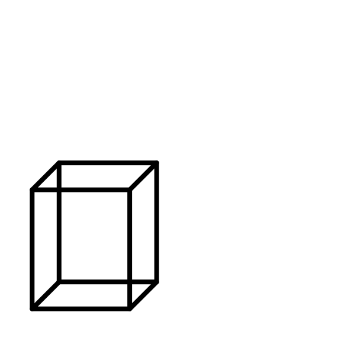

Next, plywood is placed around the frame on all 6 sides.

Lastly, the box is filled with cement.

Another builder wants to build a similar box, but they want the box to be scaled by a factor of 2. (Each length is scaled by multiplying by 2.)

## Answerlist

- 94
- 96
- 98
- 100
- 102
- 363
- 365
- 367
- 369
- 371
- 419
- 421
- 423
- 425
- 427
- 193
- 195
- 197
- 199
- 201
- 1465
- 1467
- 1469
- 1471
- 1473
- 3363
- 3365
- 3367
- 3369
- 3371

# Solution

- 99.6 meters
- 367.36 square meters
- 420.9 cubic meters
- 199.2 meters
- 1469.44 square meters
- 3367.2 cubic meters

# Meta-information

extype: cloze exclozetype: schoice|schoice|schoice|schoice|schoice|schoice exsolution: 00010|00100|01000|00010|00100|00100 exname: scale_rectangular_prism